# Gibt es gefälschte Interviews im ESS Round 1 Hungary

Appendix

Kevin Glock

29 Januar, 2021

Abstract

Inhalt: Gesamte Analyse der Hausarbeit

# 1 required libraries

These libraries are used for the analysis.

```r
library(foreign)  # read.spss
library(dplyr)  # using pipes
library(haven)  # read_por
library(DT)  # interctive datatable
```

# 2 load respondents data

Get the data on respondents.

```r
resp <- read.spss("C:/Users/k_glo/Desktop/Kevin/Uni Unterlagen/2_Arbeitsmaterialien/2_Master/1. Fachsemester/1_DataCol_n_Error/12_Hausarbeit/data/ESS1HU.sav",
    to.data.frame = T, use.value.labels = F)  # data on respondents

# dim(resp) # 1685 entries and 566 variables
```

Get the data on interviewers.

```r
int <- read_por("C:/Users/k_glo/Desktop/Kevin/Uni Unterlagen/2_Arbeitsmaterialien/2_Master/1. Fachsemester/1_DataCol_n_Error/12_Hausarbeit/data/ESS1cfHU.por")  # data on interviewers

# dim(int) # 2484 entries and 176 variables
```

# 3 merge data

Get rid of not used variables and merge the sets to a new merged subset.

```r
data1 <- subset.data.frame(resp, select = -c(name, essround,
    edition, proddate, cntry, pweight, pspwght, dweight, ctzship,
    cntbrth, lnghoma, lnghomb))  # remove irrelevant and character variables

# dim(data1) # 1685 entries and 554 variables

data2 <- subset.data.frame(int, select = c(IDNO, INTNUM1, INTNUM2,
    INTNUM3, TOTCINT1, TOTCINT2, TOTCINT3))  #; dim(data2) # 2484 entries and 7 variables

mergeddata <- merge(data1, data2, by.x = "idno", by.y = "IDNO",
    sort = T, no.dups = F)

mergeddata <- mergeddata %>% select(idno, INTNUM1, TOTCINT1,
    INTNUM2, TOTCINT2, INTNUM3, TOTCINT3, everything())  #; dim(mergeddata) # 1685 entries and 560 variables

# head(mergeddata, n=10)
```

# 4 Interactive datatable

Get an overview.

```r
datatable(mergeddata[-c(20:1685), -c(31:560)], rownames = FALSE,
    options(list(className = "dt-center", targets = 4, width = "10")))
```

| idno | INTNUM1 | TOTCINT1 | INTNUM2 | TOTCINT2 | INTNUM3 | TOTCINT3 | tvtot | tvpol | rdtot | rdpol | nwsptot | nwsppol | netuse | ppltrst | pplfair | pplhlp | polintr | polcmpl | polactiv | poldcs | pltcare | pltinvt | trstprl | trstlgl | trstplc | trstplt | trstep | trstun | vote |
| --- | --- | --- | --- | --- | --- | --- | --- | --- | --- | --- | --- | --- | --- | --- | --- | --- | --- | --- | --- | --- | --- | --- | --- | --- | --- | --- | --- | --- | --- |
| 2 | 6049 | 1 |  | 99 |  | 99 | 2 | 1 | 2 | 1 | 1 | 1 | 2 | 7 | 6 | 5 | 2 | 1 | 2 | 3 | 3 | 4 | 7 | 5 | 5 | 6 | 8 | 8 | 1 |
| 3 | 6049 | 99 |  | 99 |  | 99 | 2 | 1 | 0 |  | 0 |  | 3 | 6 | 6 | 4 | 3 | 4 | 1 | 3 | 2 | 2 | 8 | 4 | 3 | 4 | 8 | 9 | 1 |
| 4 | 6049 | 1 |  | 99 |  | 99 | 1 | 1 | 7 | 2 | 0 |  | 1 | 5 | 8 | 7 | 3 | 3 | 1 | 3 | 2 | 2 | 5 | 5 | 5 | 5 | 6 | 6 | 2 |
| 5 | 6049 | 1 |  | 99 |  | 99 | 1 | 0 | 2 | 0 | 4 | 0 | 6 | 1 | 0 | 2 | 4 | 2 | 1 | 3 | 4 | 2 | 4 | 0 | 1 | 0 | 0 | 3 | 2 |
| 6 | 6049 | 99 |  | 99 |  | 99 | 5 | 1 | 1 | 0 | 5 | 1 | 0 | 5 | 8 | 7 | 3 | 4 | 1 | 2 | 2 | 2 | 3 | 3 | 4 | 2 | 5 | 5 | 1 |
| 7 | 6049 | 99 |  | 99 |  | 99 | 2 | 0 | 3 | 1 | 0 |  | 1 | 4 | 4 | 4 | 3 | 5 | 1 | 1 | 2 | 1 | 6 | 10 | 10 | 4 |  |  | 2 |
| 8 | 6049 | 99 |  | 99 |  | 99 | 4 | 1 | 7 | 2 | 0 |  | 1 | 1 | 2 | 1 | 3 | 4 | 1 |  | 1 | 1 | 5 | 5 | 8 | 5 |  |  | 2 |
| 9 | 6049 | 99 |  | 99 |  | 99 | 6 | 1 | 0 |  | 0 |  | 1 | 0 | 5 | 1 | 3 | 2 | 1 | 4 | 4 | 2 | 5 | 6 | 6 | 7 | 10 | 10 | 2 |
| 11 | 6049 | 99 |  | 99 |  | 99 | 2 | 1 | 1 | 1 | 1 | 1 | 1 | 3 | 2 | 3 | 2 | 2 | 3 | 4 | 4 | 2 | 4 | 4 | 2 | 2 | 3 | 3 | 1 |
| 12 | 6049 | 99 |  | 99 |  | 99 | 6 | 2 | 7 | 6 | 1 | 1 | 1 | 0 | 3 | 0 | 3 | 4 | 1 | 3 | 3 | 3 | 6 | 7 | 3 | 5 | 5 | 10 | 1 |

[output cut: 9 more lines]

# 5 Methodological infos on dataset

Total non response rate.

```r
2484 - 1685  #=799

(799 * 100)/2484  #=32.17 %
1 - 0.3217  # 67.83 %
(1685/2484) * 100  # 67.83%
```

How many interviewer?

```r
unique(int$INTNUM1)  # 199 unique interviewer who started first contact
unique(int$INTNUM2)  # 19
unique(int$INTNUM3)  # 2


# sum(table(int$INTNUM1)) 2461 first contacts 2484-2461=23
# NAs

# sum(table(int$INTNUM2)) # 35 re-issues
# sum(table(int$INTNUM3)) # 4 re-issues

# table(int$TOTCINT1) table(int$TOTCINT2) table(int$TOTCINT3)


# 436+224+124+45+7+2=838 436+224+124+45+937=1766

rm(list = c("resp", "int"))
```

How many total contacts being made by the interviews?

```r
data5.0 <- mergeddata %>% subset(mergeddata$TOTCINT1 == 0)
data5.1 <- mergeddata %>% subset(mergeddata$TOTCINT1 == 1)
data5.2 <- mergeddata %>% subset(mergeddata$TOTCINT1 == 2)
data5.3 <- mergeddata %>% subset(mergeddata$TOTCINT1 == 3)
data5.4 <- mergeddata %>% subset(mergeddata$TOTCINT1 == 4)
data5.5 <- mergeddata %>% subset(mergeddata$TOTCINT1 == 5)
data5.6 <- mergeddata %>% subset(mergeddata$TOTCINT1 == 6)
data5.7 <- mergeddata %>% subset(mergeddata$TOTCINT1 == 7)
data5.8 <- mergeddata %>% subset(mergeddata$TOTCINT1 == 8)
data5.9 <- mergeddata %>% subset(mergeddata$TOTCINT1 == 9)
data5.10 <- mergeddata %>% subset(mergeddata$TOTCINT1 == 10)
# dim(data5.0) # 689 for all desired interviews resp. 513 for
# all performed interview dim(data5.1) # 436 resp. 336
# dim(data5.2) # 224 resp. 147 dim(data5.3) # 124 resp. 69
# dim(data5.4) # 45 resp. 20 dim(data5.5) # 16 resp. 7
# dim(data5.6) # 8 resp. 2 dim(data5.7) # 2 resp. 1
# dim(data5.8) # 1 resp. 0 dim(data5.9) # 2 resp. 0
# dim(data5.10)# 0 resp. 0

data5.0.1 <- mergeddata %>% subset(mergeddata$TOTCINT2 == 0)
data5.1.1 <- mergeddata %>% subset(mergeddata$TOTCINT2 == 1)
data5.2.1 <- mergeddata %>% subset(mergeddata$TOTCINT2 == 2)

# dim(data5.0.1) # 7 resp. 7 dim(data5.1.1) # 4 resp. 4
# dim(data5.2.1) # 0 resp. 0

data5.0.2 <- mergeddata %>% subset(mergeddata$TOTCINT3 == 0)
data5.1.2 <- mergeddata %>% subset(mergeddata$TOTCINT3 == 1)
data5.2.2 <- mergeddata %>% subset(mergeddata$TOTCINT3 == 2)

# dim(data5.0.2) # 1 resp. 1 dim(data5.1.2) # 1 resp. 0
# dim(data5.2.1) # 0 resp. 0

rm(list = c("data5.0", "data5.1", "data5.2", "data5.3", "data5.4",
    "data5.5", "data5.6", "data5.7", "data5.8", "data5.9", "data5.10",
    "data5.0.1", "data5.1.1", "data5.2.1", "data5.3.1", "data5.4.1",
    "data5.5.1", "data5.6.1", "data5.7.1", "data5.8.1", "data5.9.1",
    "data5.10.1", "data5.0.2", "data5.1.2", "data5.2.2"))
```

## 5.1 methodological subset infos

How many interviewer?

```r
length(unique(mergeddata[, "INTNUM1"]))  # 193 interviewers
length(unique(mergeddata[, "INTNUM2"]))  # 16 interviewers
length(unique(mergeddata[, "INTNUM3"]))  # 1 interviewer
```

# 6 variability approach

For the variability approach in the first step the variance for each interviewer and every question is calculated and summed up. The difference between each observation for a question by interviewer and the mean of the question will provide a t-statistic which can be tested against a resampled distribution.

```r
# dim(mergeddata)

anew <- subset.data.frame(mergeddata, select = -c(3, 5, 7)) %>%
    group_by(idno, INTNUM1)  # sort it by interviewer and match each interview

# head(anew, n = 5)

anew[is.na(anew)] <- 0  # All NAs should be 0 because of calculations

# dim(anew) head(anew, n = 5) # Now the data is tidy; 1685
# obs on 557 var
```

## 6.1 calculate the means

Pay attention for 1685 entries, 557 total columns but idno and INTNUM1-3 should not be includes.

```r
bnew <- anew[, c(5:557)] %>% colMeans() %>% rbind.data.frame()

names(bnew) <- colnames(anew[5:557])

# head(bnew, n = 5) # now we have the mean values for every
# variable

bnew <- bnew[rep(seq_len(ncol(bnew)), each = 1685), ]  # each must be adapted

# head(bnew, n = 5) (bnew, n = 5)

bnew <- bnew[-c(1686:nrow(bnew)), ]  # make sure there are no redundant rows

# nrow(bnew) # 1685

# now we have a df with all means for every variable for each
# observation we have to apply the calculation for each
# observation

# head(anew, n = 5)

cnew <- anew[, -(1:4)]  # we have to remove idno and INTNUM1-3 to make rowwise calculations in the next step

# dim(cnew) # stated values for each interview; 1685 obs and
# 553 vars dim(bnew) # mean for each question; 1685 obs and
# 553 vars
```

## 6.2 calculate variabilities

Variability for each question over each interview

```r
calc <- (cnew - bnew)^2
# head(calc, n = 5)

calc2 <- cbind(anew[, c("idno", "INTNUM1", "INTNUM2", "INTNUM3")],
    calc)

# dim(calc2) # like before 1685 obs on 557 vars head(calc2, n
# = 5)

calc3 <- calc2 %>% group_by(INTNUM1, INTNUM2, INTNUM3) %>% summarise(.groups = "keep",
    across(.cols = 5:554, .fns = sum))  # sum up for each interviewer over all questions

rm(list = c("anew", "bnew", "cnew"))

# dim(calc3) # 208 obs because of grouping by INTNUM1-3 and
# 553 vars head(calc3, n = 5)
```

## 6.3 get the test statistic T

Get the test statistic T (total variability) for the clustered interviewer and for the whole survey.

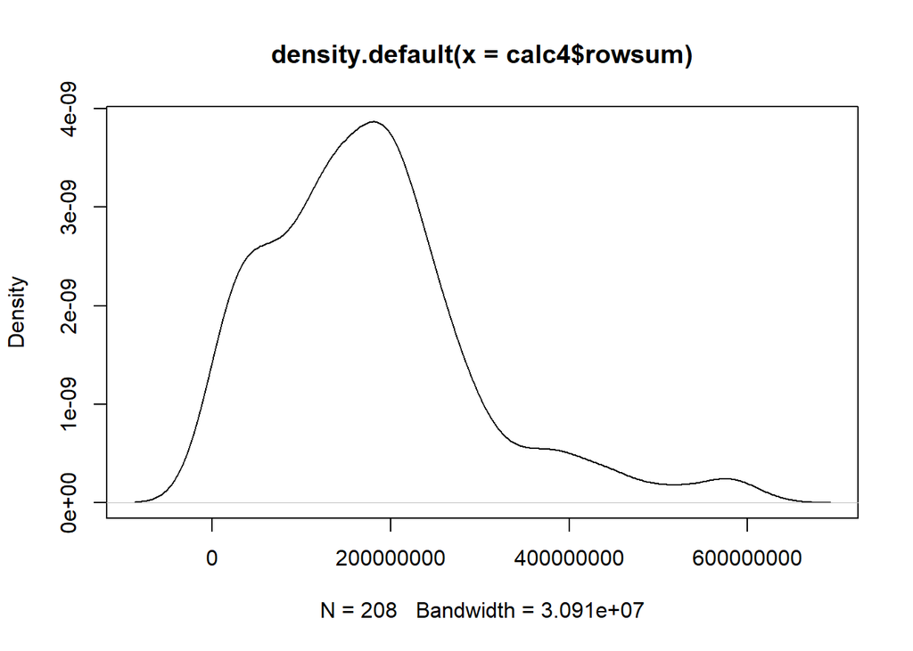

```r
calc4 <- cbind.data.frame(calc3[c("INTNUM1", "INTNUM2", "INTNUM3")],
    rowsum = rowSums(calc3[4:553]))  # create a new object containing the INTNUMs and the total variability aggregated by INTNUMs

sort.calc4 <- calc4[order(calc4$rowsum), ]  # resort it by the rowsums to get ascending values of the variabilities

# head(sort.calc4, n = 5)

plot(density(calc4$rowsum))
```

```r
options(scipen = 5)  # the density of variability over all interviewers

sd(calc4$rowsum)  # 119066864
mean(calc4$rowsum)  # 176699700

sort(table(calc4$INTNUM1))  # we can see that some are double or triple this is because they are re-issued by a second and third person
# head(calc4, n = 20) # look on the entries 6 and 7 for
# example

length(which(sort.calc4$rowsum < 1e+08))  # fifty-seven interviews show suspiciously low total variabilities at first sight

# head(sort.calc4, n = 5) # lowest value 6044290 for
# interviewer 2086; keep in mind that this are aggregated
# values!  tail(sort.calc4, n = 5) # highest value 599664843
# for interviewer 6049
```

## 6.4 whole dataset

Get independent variabilities for the interviews.

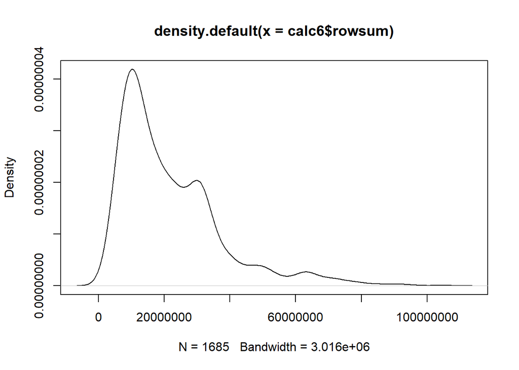

```r
calc5 <- cbind(calc2[c("idno", "INTNUM1")], calc)  #; head(calc5, n = 5)

calc6 <- cbind.data.frame(calc5[c("idno", "INTNUM1")], rowsum = rowSums(calc5[3:554]))  #; head(calc6, n = 5)

plot(density(calc6$rowsum))  # density plot for unique interviews not grouped by interviewers
```

```r
sd(calc6$rowsum)  # 15601634
mean(calc6$rowsum)  #21812202

sort.calc6 <- calc6[order(calc6$rowsum), ]  # now sorted by rowsums not by respondends ID

# head(sort.calc6, n = 5) # lowest value 2352503 for
# interview 2308; keep in mind that this are seperated
# interview values not aggregated tail(sort.calc6, n = 5) #
# highest value 104602583 for interview 2089
```

# 7 clustering first step

Get tidy data for clustering. Write a csv and extract infos to get an overview of the ranking.

```r
# getwd()

# write.csv2(sort.calc6, '2sorted_ranking_calc6.csv',sep =
# ';')

# sort(table(mergeddata$INTNUM1)) head(mergeddata, n = 5)

Intnum_count_each <- mergeddata[, -c(3:length(mergeddata))] %>%
    rowwise %>% mutate(time = list(rep(INTNUM1)))  # repeat the INTNUM1 based on its counts

# head(Intnum_count_each, n = 5)

length(unique(Intnum_count_each$INTNUM1))  # 193 unique interviewers

Intnum_count_each2 <- Intnum_count_each %>% group_by(INTNUM1) %>%
    mutate(count = n())  # put in a occurrence variable

# head(Intnum_count_each2, n = 5)

Intnum_count <- Intnum_count_each2[, -c(3)] %>% group_by(INTNUM1,
    count) %>% mutate(count = n())  # grouping and erase irrelevant var

rm(list = c("Intnum_count_each", "Intnum_count_each2"))

# head(Intnum_count, n = 5)
```

## 7.1 clustering second step

Create a new object containing the counts.

```r
rowsum_by_idno_intnum <- calc6 %>% group_by(INTNUM1) %>% mutate(count = n())  #; head(rowsum_by_idno_intnum, n = 5)

rowsum_by_idno_intnum2 <- rowsum_by_idno_intnum[, -c(2, 4)]  # one dataset with only the idno and rowsum
# head(rowsum_by_idno_intnum2, n = 5)
```

Create new subsets based on the number of interviews an interviewer had to compare them within the groups.

```r
o1 <- rowsum_by_idno_intnum %>% subset(count == 1)
o1 <- o1[, -4]

o1 %>% mutate_each_(funs(scale), vars = c("rowsum"))
# head(o1)

o2 <- rowsum_by_idno_intnum %>% subset(count == 2)
o2 <- o2[, -4]

o2 %>% mutate_each_(funs(scale), vars = c("rowsum"))
# head(o2)

o3 <- rowsum_by_idno_intnum %>% subset(count == 3)
o3 <- o3[, -4]

o3 %>% mutate_each_(funs(scale), vars = c("rowsum"))
# head(o3)

o4 <- rowsum_by_idno_intnum %>% subset(count == 4)
o4 <- o4[, -4]

o4 %>% mutate_each_(funs(scale), vars = c("rowsum"))
# head(o4)

o5 <- rowsum_by_idno_intnum %>% subset(count == 5)
o5 <- o5[, -4]

o5 %>% mutate_each_(funs(scale), vars = c("rowsum"))
# head(o5)

o6 <- rowsum_by_idno_intnum %>% subset(count == 6)
o6 <- o6[, -4]

o6 %>% mutate_each_(funs(scale), vars = c("rowsum"))
# head(o6)

o7 <- rowsum_by_idno_intnum %>% subset(count == 7)
o7 <- o7[, -4]

o7 %>% mutate_each_(funs(scale), vars = c("rowsum"))
# head(o7)

o8 <- rowsum_by_idno_intnum %>% subset(count == 8)
o8 <- o8[, -4]

o8 %>% mutate_each_(funs(scale), vars = c("rowsum"))
# head(o8)

o9 <- rowsum_by_idno_intnum %>% subset(count == 9)
o9 <- o9[, -4]

o9 %>% mutate_each_(funs(scale), vars = c("rowsum"))
# head(o9)

o10 <- rowsum_by_idno_intnum %>% subset(count == 10)
o10 <- o10[, -4]

o10 %>% mutate_each_(funs(scale), vars = c("rowsum"))
# head(o10)

o11 <- rowsum_by_idno_intnum %>% subset(count == 11)
o11 <- o11[, -4]

o11 %>% mutate_each_(funs(scale), vars = c("rowsum"))
# head(o11)

o12 <- rowsum_by_idno_intnum %>% subset(count == 12)
o12 <- o12[, -4]

o12 %>% mutate_each_(funs(scale), vars = c("rowsum"))
# head(o12)

o13 <- rowsum_by_idno_intnum %>% subset(count == 13)
o13 <- o13[, -4]

o13 %>% mutate_each_(funs(scale), vars = c("rowsum"))
# head(o13)

o14 <- rowsum_by_idno_intnum %>% subset(count == 14)
o14 <- o14[, -4]

o14 %>% mutate_each_(funs(scale), vars = c("rowsum"))
# head(o14)

o15 <- rowsum_by_idno_intnum %>% subset(count == 15)
o15 <- o15[, -4]

o15 %>% mutate_each_(funs(scale), vars = c("rowsum"))
# head(o15)

o17 <- rowsum_by_idno_intnum %>% subset(count == 17)
o17 <- o17[, -4]

o17 %>% mutate_each_(funs(scale), vars = c("rowsum"))
# head(o17)

o18 <- rowsum_by_idno_intnum %>% subset(count == 18)
o18 <- o18[, -4]

o18 %>% mutate_each_(funs(scale), vars = c("rowsum"))
# head(o18)

o20 <- rowsum_by_idno_intnum %>% subset(count == 20)
o20 <- o20[, -4]

o20 %>% mutate_each_(funs(scale), vars = c("rowsum"))
# head(o20)

o21 <- rowsum_by_idno_intnum %>% subset(count == 21)
o21 <- o21[, -4]

o21 %>% mutate_each_(funs(scale), vars = c("rowsum"))
# head(o21)

o22 <- rowsum_by_idno_intnum %>% subset(count == 22)
o22 <- o22[, -4]

o22 %>% mutate_each_(funs(scale), vars = c("rowsum"))
# head(o22)

o27 <- rowsum_by_idno_intnum %>% subset(count == 27)
o27 <- o27[, -4]

o27 %>% mutate_each_(funs(scale), vars = c("rowsum"))
# head(o27)
```

# 8 clustering third step

Create distant matrices.

```r
## with all interviews

dist.fun0 <- dist(rowsum_by_idno_intnum, method = "euclidean")


## only with one interview

dist.fun1 <- dist(o1, method = "euclidean")


## only with two interviews

dist.fun2 <- dist(o2, method = "euclidean")


## only with three interviews

dist.fun3 <- dist(o3, method = "euclidean")


## only with four interviews

dist.fun4 <- dist(o4, method = "euclidean")


## only with five interviews

dist.fun5 <- dist(o5, method = "euclidean")


## only with six interviews

dist.fun6 <- dist(o6, method = "euclidean")


## only with seven interviews

dist.fun7 <- dist(o7, method = "euclidean")


## only with eight interviews

dist.fun8 <- dist(o8, method = "euclidean")


## only with nine interviews

dist.fun9 <- dist(o9, method = "euclidean")


## only with ten interviews

dist.fun10 <- dist(o10, method = "euclidean")


## only with eleven interviews

dist.fun11 <- dist(o11, method = "euclidean")


## only with twelve interviews

dist.fun12 <- dist(o12, method = "euclidean")


## only with thirteen interviews

dist.fun13 <- dist(o13, method = "euclidean")


## only with fourteen interviews

dist.fun14 <- dist(o14, method = "euclidean")


## only with fifteen interviews

dist.fun15 <- dist(o15, method = "euclidean")


## only with seventeen interviews

dist.fun17 <- dist(o17, method = "euclidean")


## only with eighteen interviews

dist.fun18 <- dist(o18, method = "euclidean")


## only with twenty interviews

dist.fun20 <- dist(o20, method = "euclidean")


## only with twenty-one interviews

dist.fun21 <- dist(o21, method = "euclidean")


## only with twenty-two interviews

dist.fun22 <- dist(o22, method = "euclidean")


## only with twenty-seven interviews

dist.fun27 <- dist(o27, method = "euclidean")
```

# 9 clustering last step

Create hierarical clusters.

```r
## overall

fit.0 <- hclust(dist.fun0, method = "single")

fit0.2 <- hclust(dist.fun0, method = "ward.D2")


## only with one interview

fit.1 <- hclust(dist.fun1, method = "single")

fit1.2 <- hclust(dist.fun1, method = "ward.D2")


## only with two interviews

fit.2 <- hclust(dist.fun2, method = "single")

fit2.2 <- hclust(dist.fun2, method = "ward.D2")


## only with three interviews

fit.3 <- hclust(dist.fun3, method = "single")

fit3.2 <- hclust(dist.fun3, method = "ward.D2")


## only with four interviews

fit.4 <- hclust(dist.fun4, method = "single")

fit4.2 <- hclust(dist.fun4, method = "ward.D2")


## only with five interviews

fit.5 <- hclust(dist.fun5, method = "single")

fit5.2 <- hclust(dist.fun5, method = "ward.D2")


## only with six interviews

fit.6 <- hclust(dist.fun6, method = "single")

fit6.2 <- hclust(dist.fun6, method = "ward.D2")


## only with seven interviews

fit.7 <- hclust(dist.fun7, method = "single")

fit7.2 <- hclust(dist.fun7, method = "ward.D2")


## only with eight interviews

fit.8 <- hclust(dist.fun8, method = "single")

fit8.2 <- hclust(dist.fun8, method = "ward.D2")


## only with nine interviews

fit.9 <- hclust(dist.fun9, method = "single")

fit9.2 <- hclust(dist.fun9, method = "ward.D2")


## only with ten interviews

fit.10 <- hclust(dist.fun10, method = "single")

fit10.2 <- hclust(dist.fun10, method = "ward.D2")


## only with eleven interviews

fit.11 <- hclust(dist.fun11, method = "single")

fit11.2 <- hclust(dist.fun11, method = "ward.D2")


## only with twelve interviews

fit.12 <- hclust(dist.fun12, method = "single")

fit12.2 <- hclust(dist.fun12, method = "ward.D2")


## only with thirteen interviews

fit.13 <- hclust(dist.fun13, method = "single")

fit13.2 <- hclust(dist.fun13, method = "ward.D2")


## only with fourteen interviews

fit.14 <- hclust(dist.fun14, method = "single")

fit14.2 <- hclust(dist.fun14, method = "ward.D2")


## only with fifteen interviews

fit.15 <- hclust(dist.fun15, method = "single")

fit15.2 <- hclust(dist.fun15, method = "ward.D2")


## only with seventeen interviews

fit.17 <- hclust(dist.fun17, method = "single")

fit17.2 <- hclust(dist.fun17, method = "ward.D2")


## only with eighteen interviews

fit.18 <- hclust(dist.fun18, method = "single")

fit18.2 <- hclust(dist.fun18, method = "ward.D2")


## only with twenty interviews

fit.20 <- hclust(dist.fun20, method = "single")

fit20.2 <- hclust(dist.fun20, method = "ward.D2")


## only with twenty-one interviews

fit.21 <- hclust(dist.fun21, method = "single")

fit21.2 <- hclust(dist.fun21, method = "ward.D2")


## only with twenty-two interviews

fit.22 <- hclust(dist.fun22, method = "single")

fit22.2 <- hclust(dist.fun22, method = "ward.D2")


## only with twenty-seven interviews

fit.27 <- hclust(dist.fun27, method = "single")

fit27.2 <- hclust(dist.fun27, method = "ward.D2")
```

# 10 Dendrograms

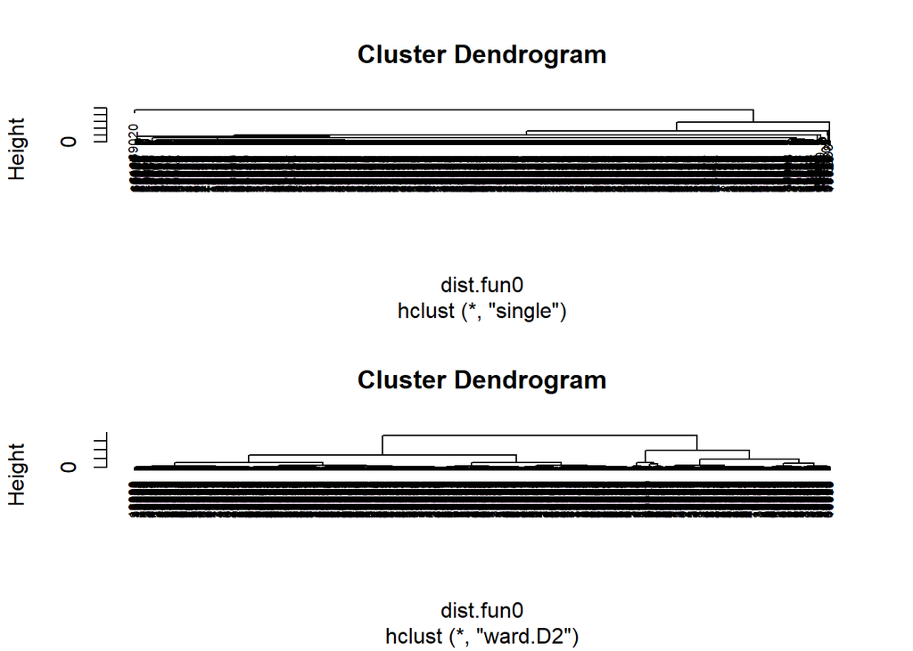

```r
par(mfrow = c(2, 1))
# Dendograms

plot(fit.0, labels = rowsum_by_idno_intnum$INTNUM1, cex = 0.6)
options(scipen = 5)
plot(fit0.2, labels = rowsum_by_idno_intnum$INTNUM1, cex = 0.6)
```

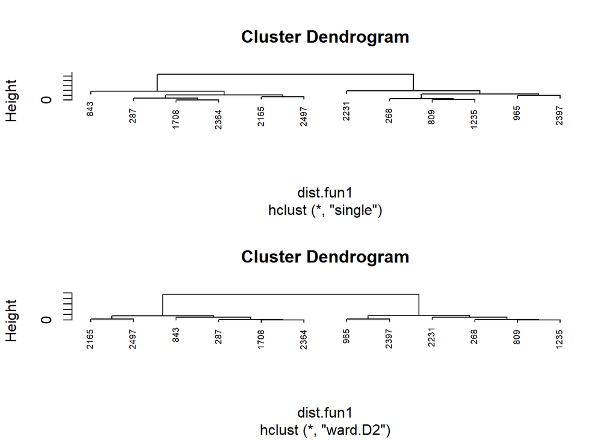

```r
options(scipen = 5)

plot(fit.1, labels = o1$idno, cex = 0.6)
options(scipen = 5)
plot(fit1.2, labels = o1$idno, cex = 0.6)
```

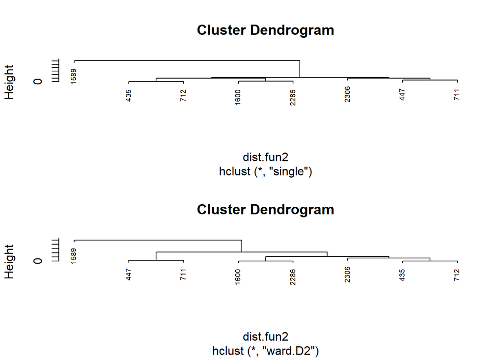

```r
options(scipen = 5)

plot(fit.2, labels = o2$idno, cex = 0.6)
options(scipen = 5)
plot(fit2.2, labels = o2$idno, cex = 0.6)
```

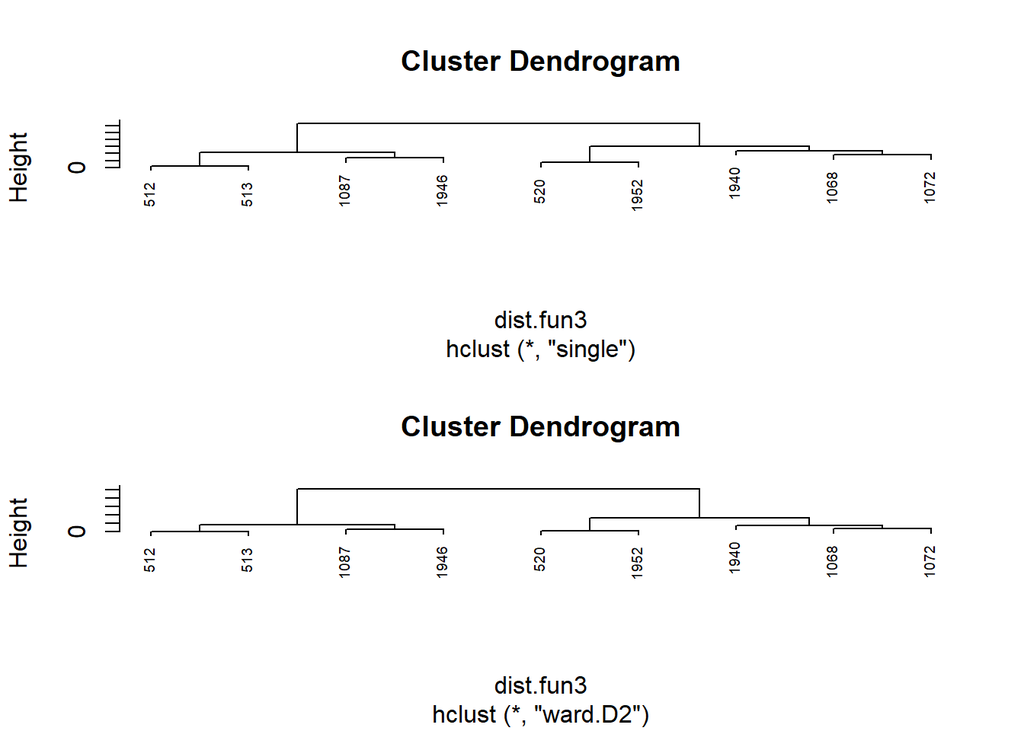

```r
options(scipen = 5)

plot(fit.3, labels = o3$idno, cex = 0.6)
options(scipen = 5)
plot(fit3.2, labels = o3$idno, cex = 0.6)
```

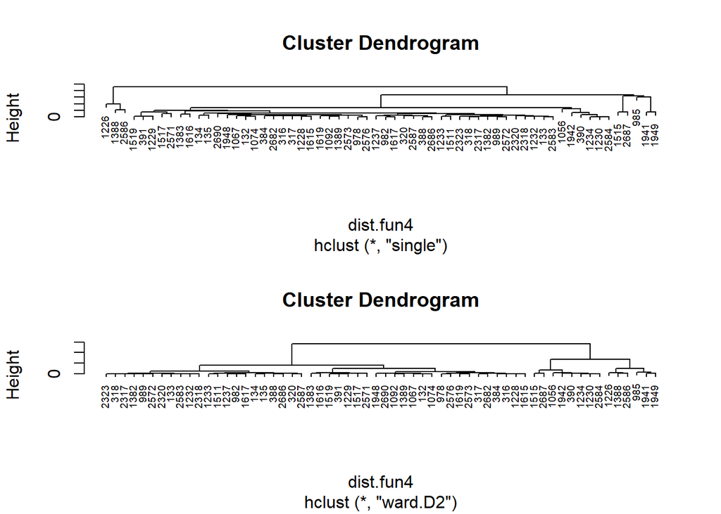

```r
options(scipen = 5)

plot(fit.4, labels = o4$idno, cex = 0.6)
options(scipen = 5)
plot(fit4.2, labels = o4$idno, cex = 0.6)
```

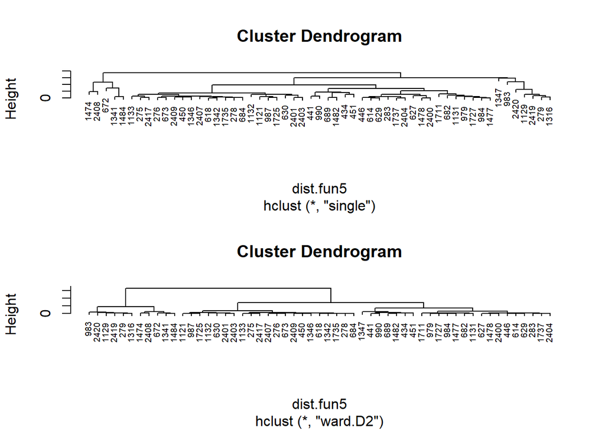

```r
options(scipen = 5)

plot(fit.5, labels = o5$idno, cex = 0.6)
options(scipen = 5)
plot(fit5.2, labels = o5$idno, cex = 0.6)
```

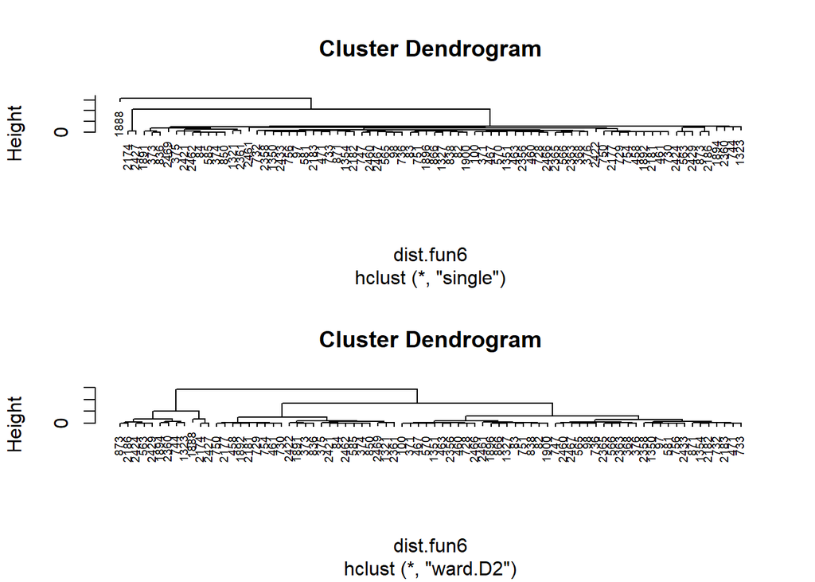

```r
options(scipen = 5)

plot(fit.6, labels = o6$idno, cex = 0.6)
options(scipen = 5)
plot(fit6.2, labels = o6$idno, cex = 0.6)
```

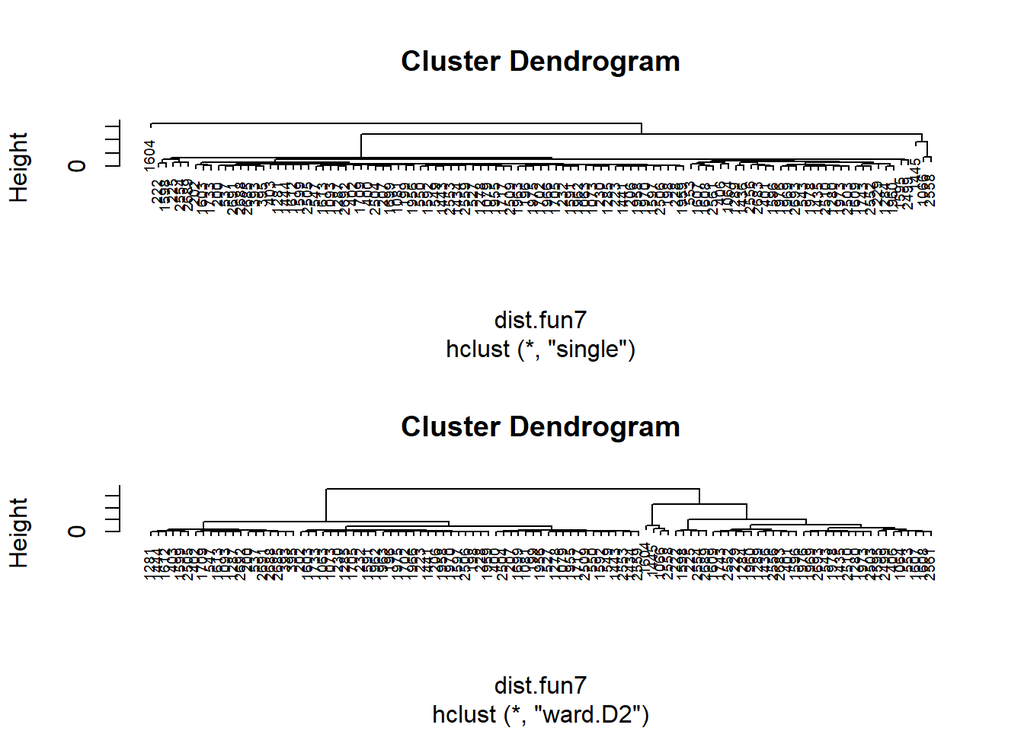

```r
options(scipen = 5)

plot(fit.7, labels = o7$idno, cex = 0.6)
options(scipen = 5)
plot(fit7.2, labels = o7$idno, cex = 0.6)
```

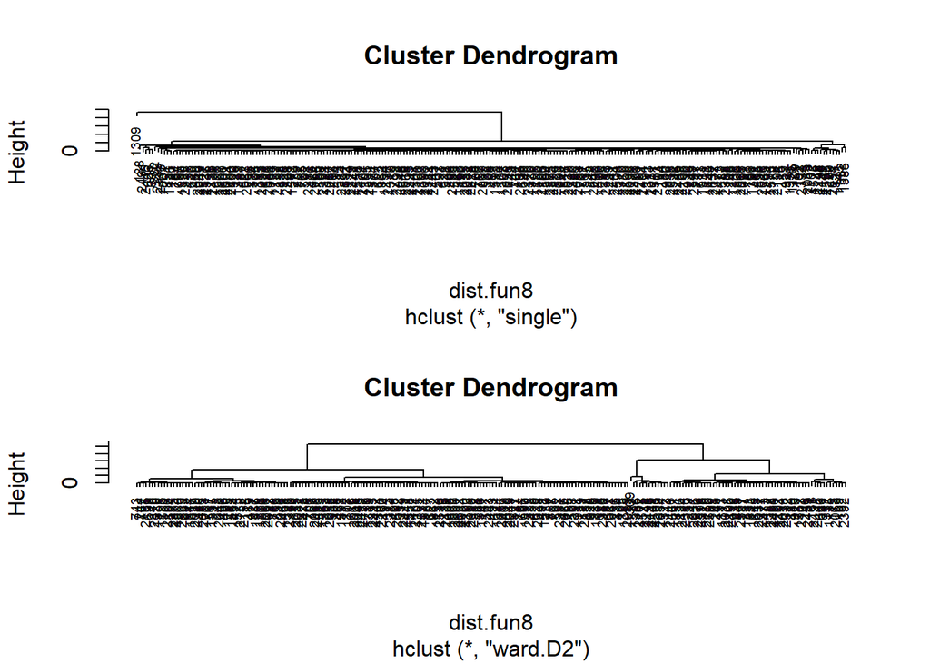

```r
options(scipen = 5)

plot(fit.8, labels = o8$idno, cex = 0.6)
options(scipen = 5)
plot(fit8.2, labels = o8$idno, cex = 0.6)
```

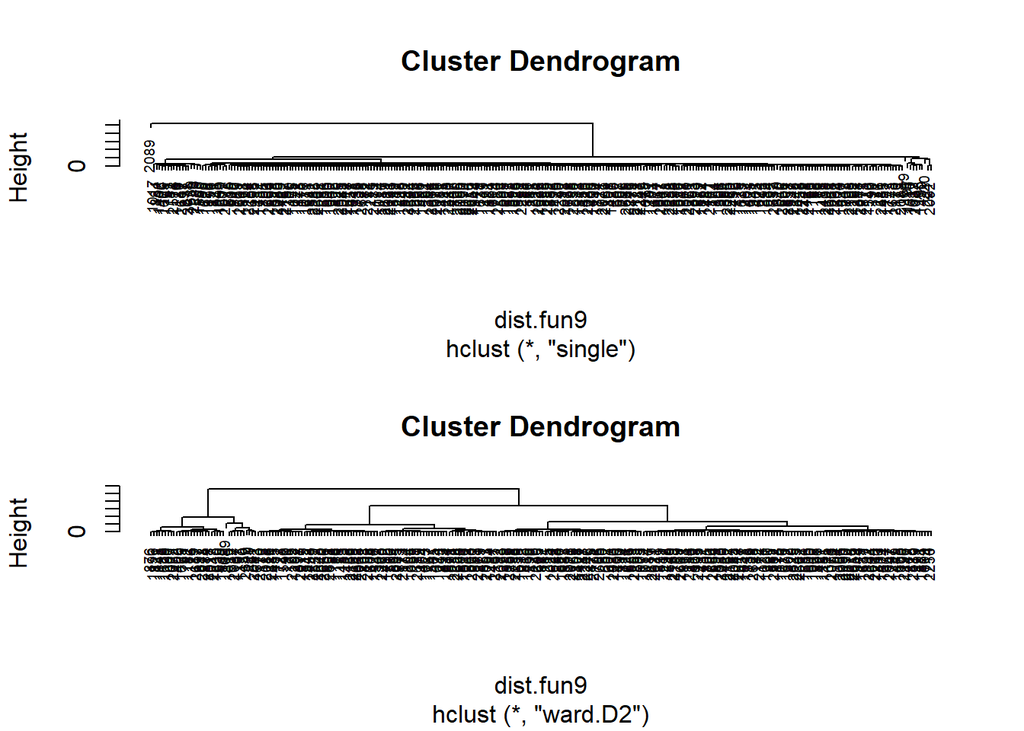

```r
options(scipen = 5)

plot(fit.9, labels = o9$idno, cex = 0.6)
options(scipen = 5)
plot(fit9.2, labels = o9$idno, cex = 0.6)
```

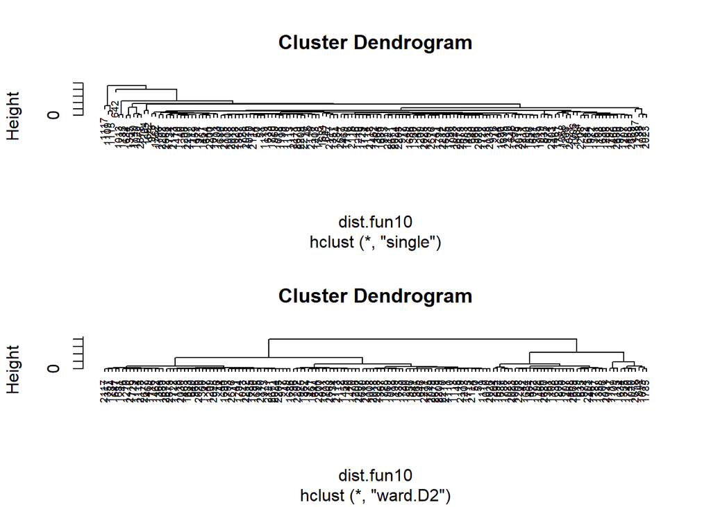

```r
options(scipen = 5)

plot(fit.10, labels = o10$idno, cex = 0.6)
options(scipen = 5)
plot(fit10.2, labels = o10$idno, cex = 0.6)
```

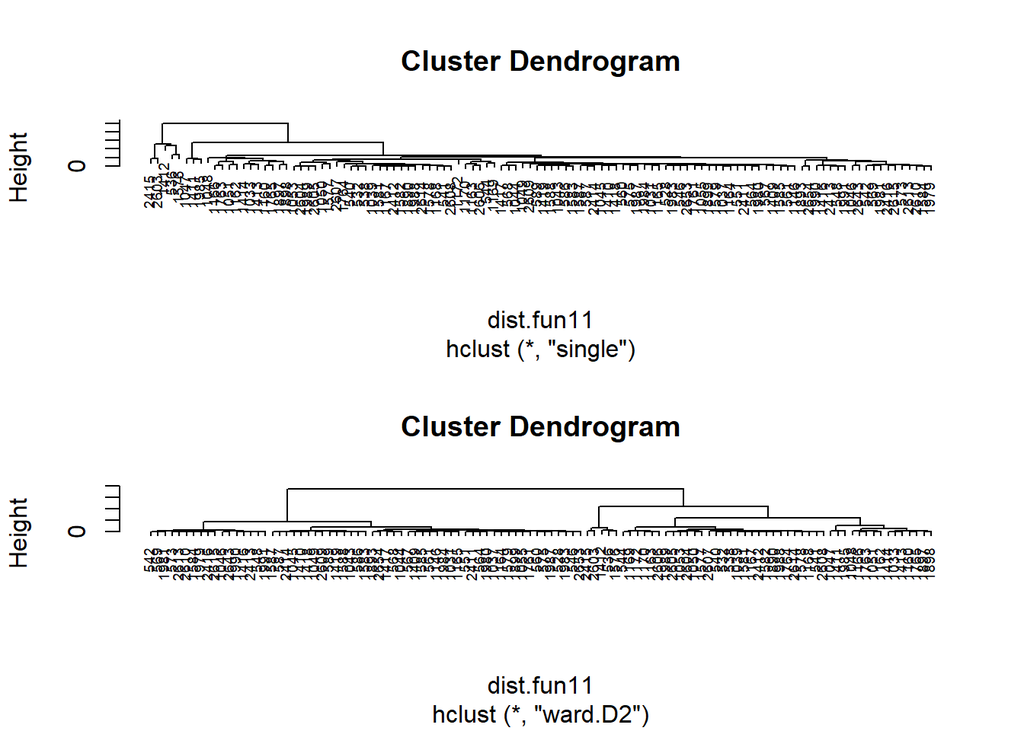

```r
options(scipen = 5)

plot(fit.11, labels = o11$idno, cex = 0.6)
options(scipen = 5)
plot(fit11.2, labels = o11$idno, cex = 0.6)
```

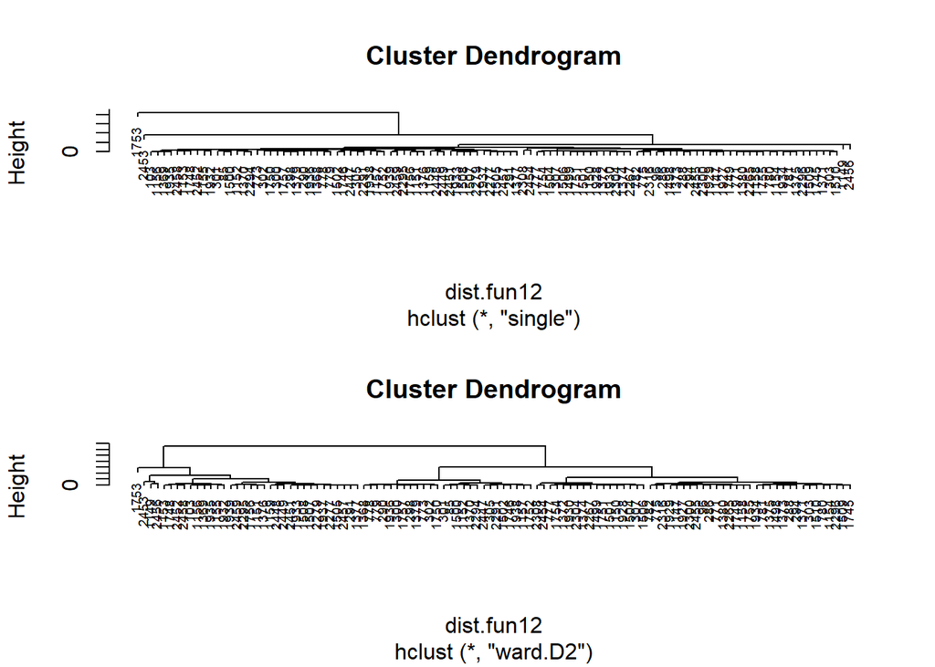

```r
options(scipen = 5)

plot(fit.12, labels = o12$idno, cex = 0.6)
options(scipen = 5)
plot(fit12.2, labels = o12$idno, cex = 0.6)
```

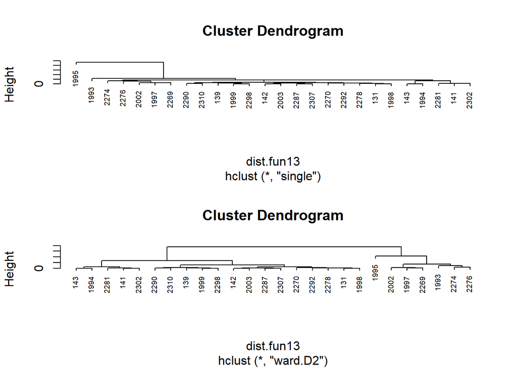

```r
options(scipen = 5)

plot(fit.13, labels = o13$idno, cex = 0.6)
options(scipen = 5)
plot(fit13.2, labels = o13$idno, cex = 0.6)
```

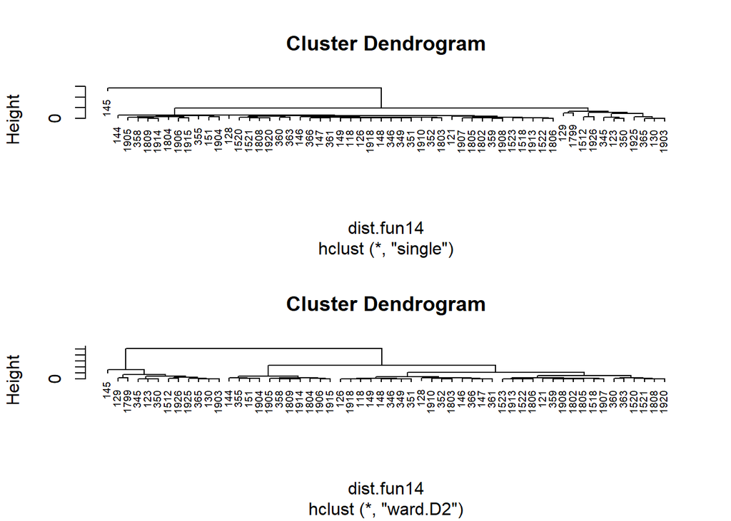

```r
options(scipen = 5)

plot(fit.14, labels = o14$idno, cex = 0.6)
options(scipen = 5)
plot(fit14.2, labels = o14$idno, cex = 0.6)
```

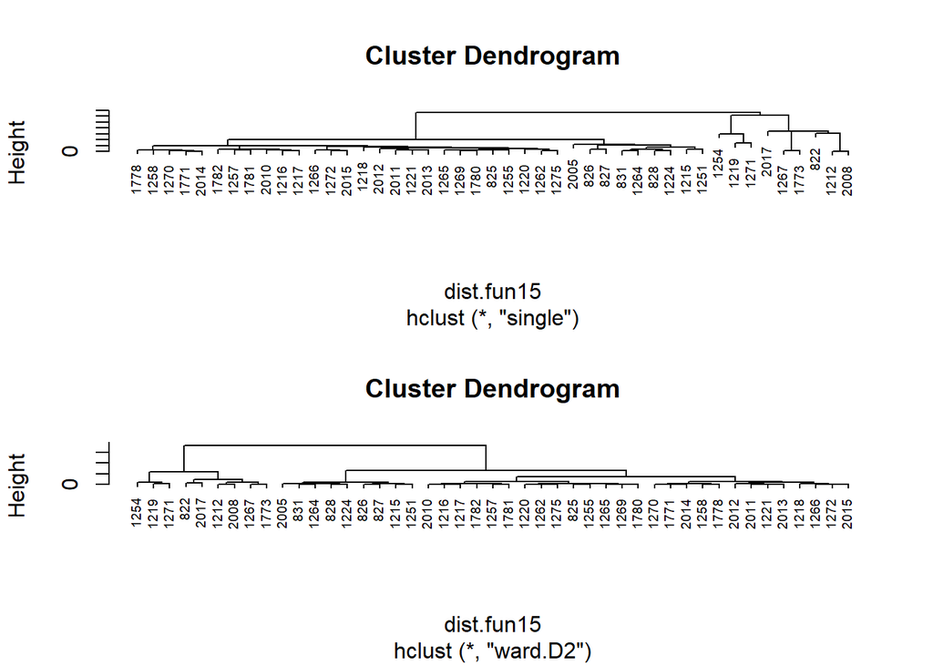

```r
options(scipen = 5)

plot(fit.15, labels = o15$idno, cex = 0.6)
options(scipen = 5)
plot(fit15.2, labels = o15$idno, cex = 0.6)
```

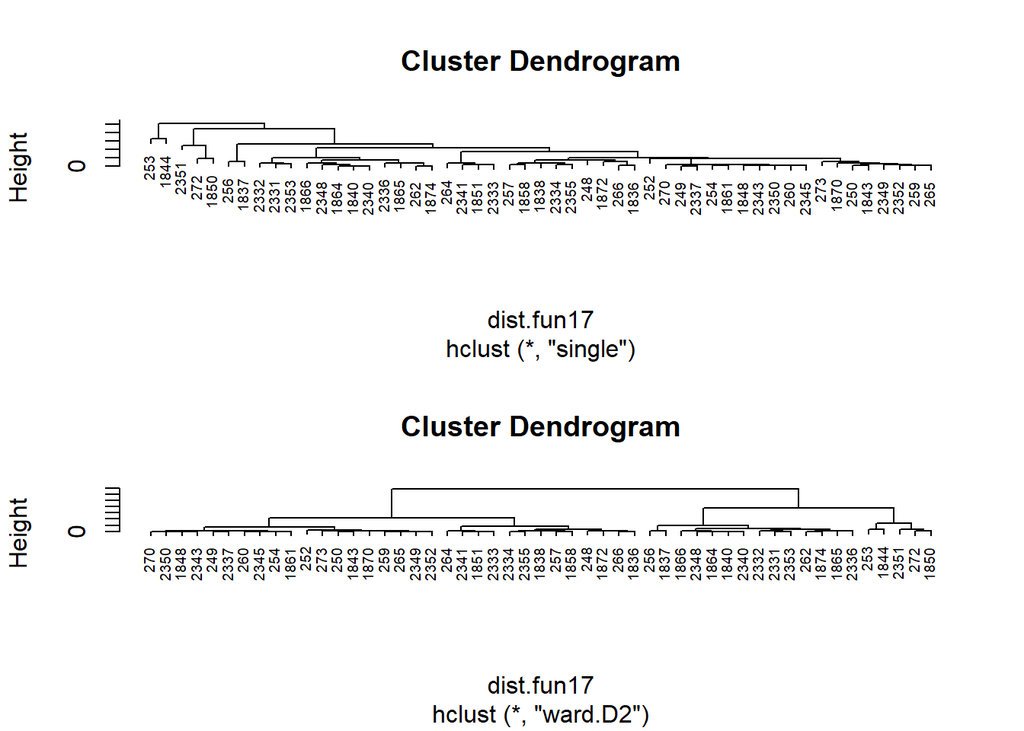

```r
options(scipen = 5)

plot(fit.17, labels = o17$idno, cex = 0.6)
options(scipen = 5)
plot(fit17.2, labels = o17$idno, cex = 0.6)
```

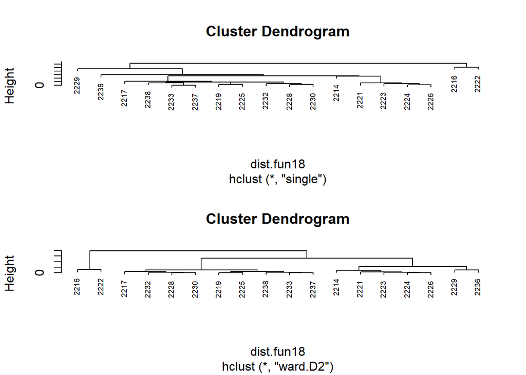

```r
options(scipen = 5)

plot(fit.18, labels = o18$idno, cex = 0.6)
options(scipen = 5)
plot(fit18.2, labels = o18$idno, cex = 0.6)
```

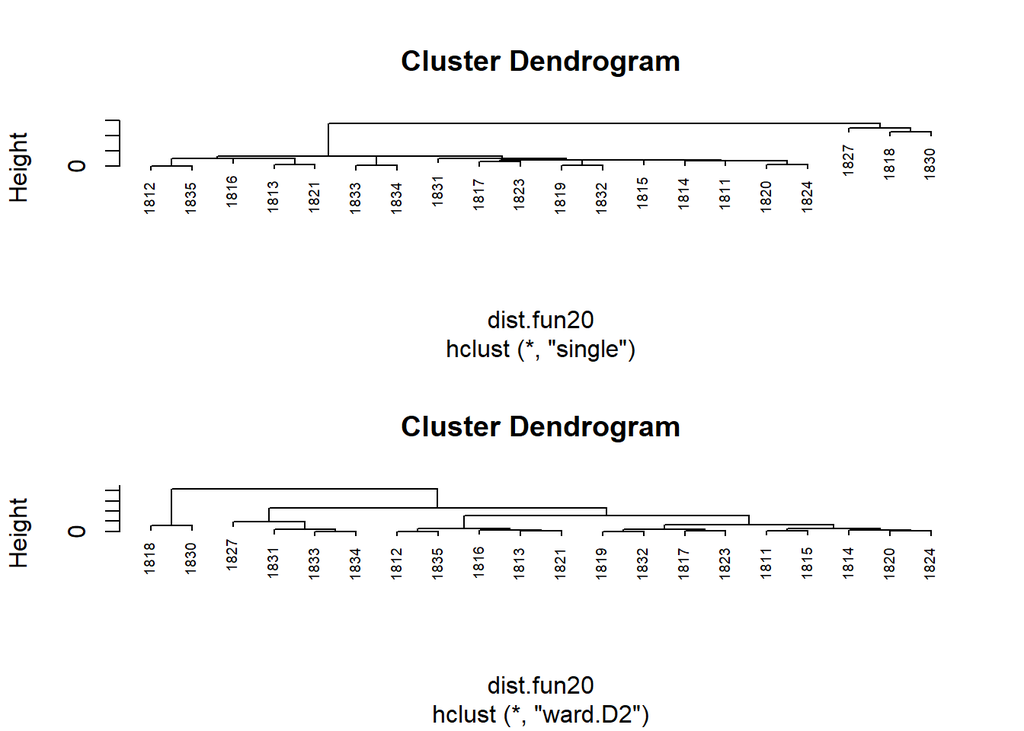

```r
options(scipen = 5)

plot(fit.20, labels = o20$idno, cex = 0.6)
options(scipen = 5)
plot(fit20.2, labels = o20$idno, cex = 0.6)
```

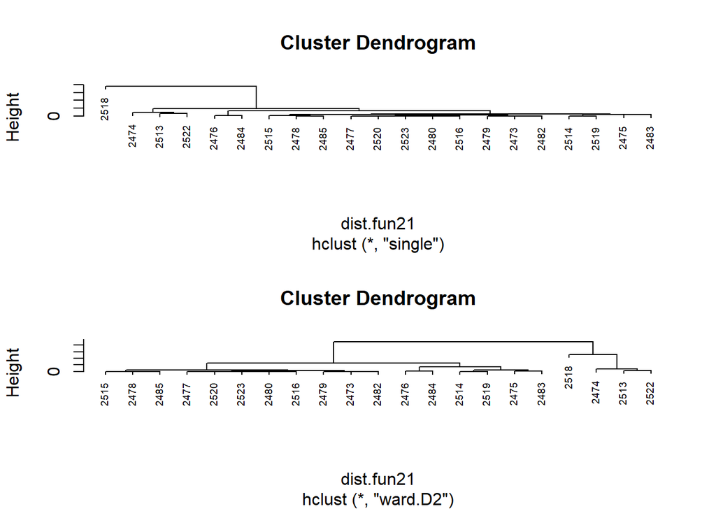

```r
options(scipen = 5)

plot(fit.21, labels = o21$idno, cex = 0.6)
options(scipen = 5)
plot(fit21.2, labels = o21$idno, cex = 0.6)
```

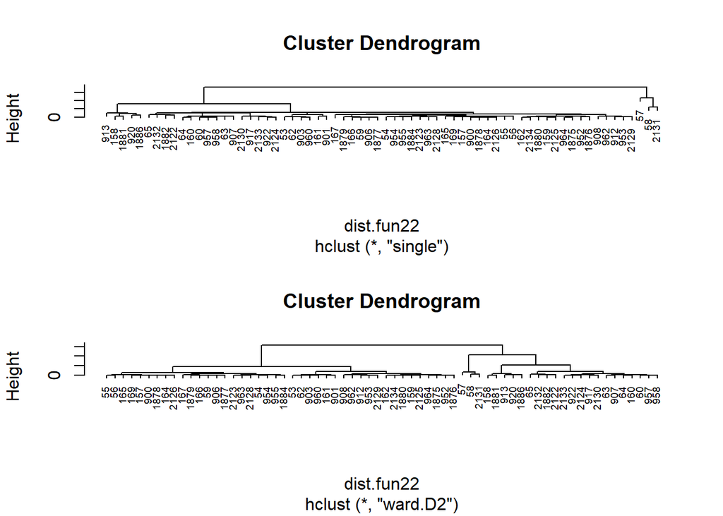

```r
options(scipen = 5)

plot(fit.22, labels = o22$idno, cex = 0.6)
options(scipen = 5)
plot(fit22.2, labels = o22$idno, cex = 0.6)
```

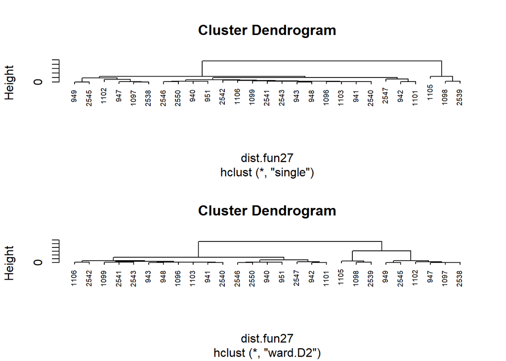

```r
options(scipen = 5)

plot(fit.27, labels = o27$idno, cex = 0.6)
options(scipen = 5)
plot(fit27.2, labels = o27$idno, cex = 0.6)
```

```r
options(scipen = 5)
```

# 11 get density plots per subgroup

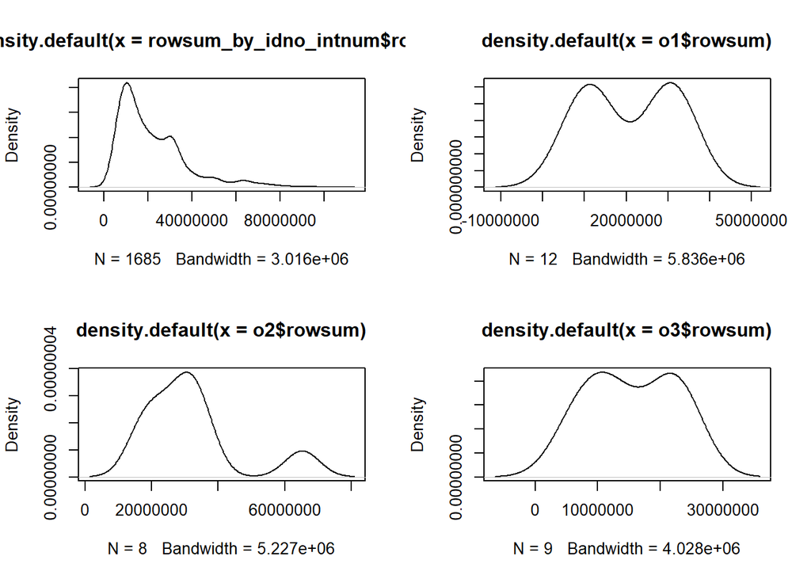

```r
par(mfrow = c(2, 2))
plot(density(rowsum_by_idno_intnum$rowsum))
options(scipen = 5)

plot(density(o1$rowsum))
options(scipen = 5)

plot(density(o2$rowsum))
options(scipen = 5)

plot(density(o3$rowsum))
```

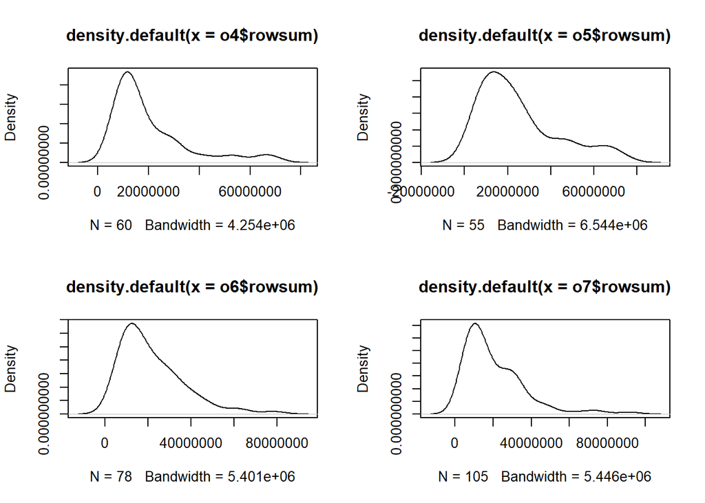

```r
options(scipen = 5)

plot(density(o4$rowsum))
options(scipen = 5)

plot(density(o5$rowsum))
options(scipen = 5)

plot(density(o6$rowsum))
options(scipen = 5)

plot(density(o7$rowsum))
```

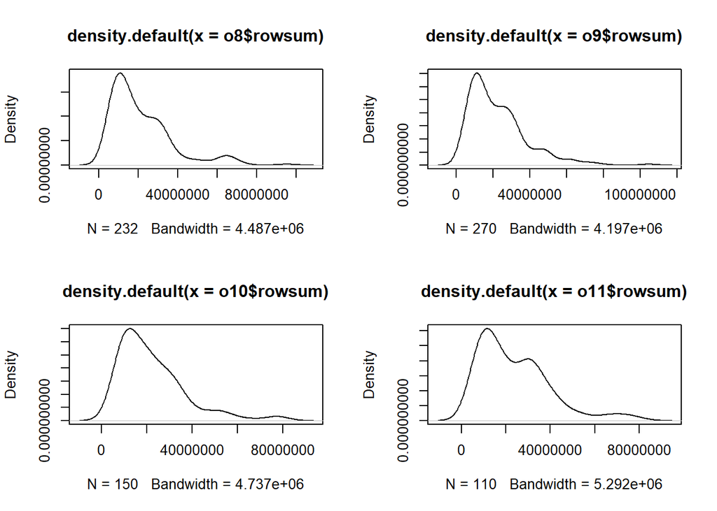

```r
options(scipen = 5)

plot(density(o8$rowsum))
options(scipen = 5)

plot(density(o9$rowsum))
options(scipen = 5)

plot(density(o10$rowsum))
options(scipen = 5)

plot(density(o11$rowsum))
```

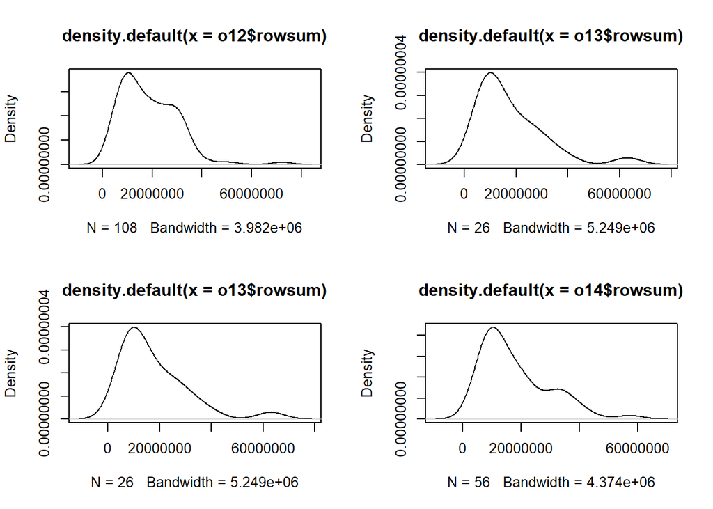

```r
options(scipen = 5)

plot(density(o12$rowsum))
options(scipen = 5)

plot(density(o13$rowsum))
options(scipen = 5)

plot(density(o13$rowsum))
options(scipen = 5)

plot(density(o14$rowsum))
```

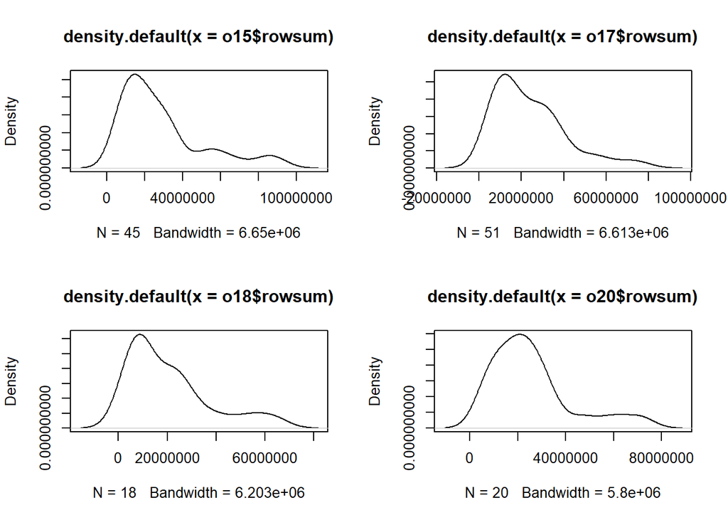

```r
options(scipen = 5)

plot(density(o15$rowsum))
options(scipen = 5)

plot(density(o17$rowsum))
options(scipen = 5)

plot(density(o18$rowsum))
options(scipen = 5)

plot(density(o20$rowsum))
```

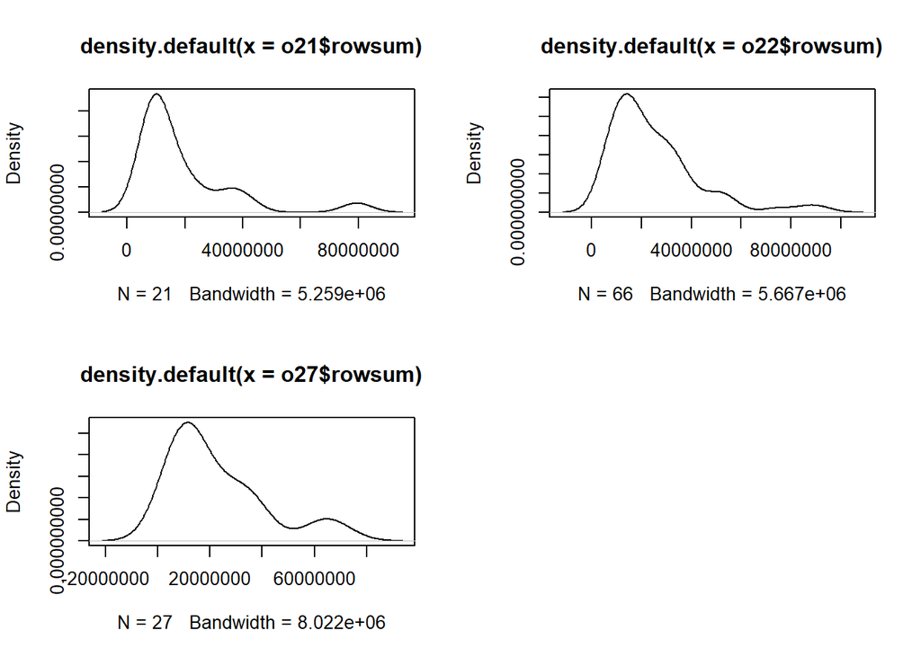

```r
options(scipen = 5)

plot(density(o21$rowsum))
options(scipen = 5)

plot(density(o22$rowsum))
options(scipen = 5)

plot(density(o27$rowsum))
options(scipen = 5)
```